# Module 9

#### Hemi-module gene counts:

227 probesets in hemi-module A.  
41 probesets in hemi-module B.  
Note: While the mapping of probesets to genes is usually one-to-one, some genes are targeted by multiple probesets, some probesets target multiple genes, and some probesets do not target any genes (i.e., the region of the genome they match is no longer considered genic).

#### Contrast SVE:

Signed variance explained (SVE) provides an indication of how similar a set of fold changes are to a gene module’s weight vector. An SVE value of 0.3, for example, indicates that 30% of the variance explained by the entire module set is accounted for by the module in question. Shown here are the SVE values for this module across a compendium of fold changes (contrasts). Extreme SVE values (e.g., > 0.05) indicate that those contrasts specifically induce (orange dots) or specifically repress (blue dots) this module. Examining the experimental conditions being compared in such contrasts (see tables below the figure) may provide insight into the gene module’s function.

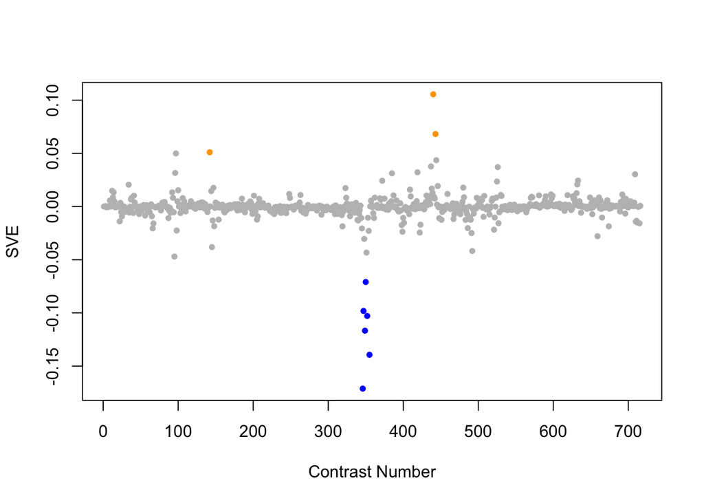

Positive SVE Contrasts:

|  | Contrast.Num | SVE | GEO.GSE | Cond.1 | Cond.2 | Mutation |
| --- | --- | --- | --- | --- | --- | --- |
| GSE27677B.s1t2.vs.s1t1 | 440 | 0.11 | GSE27677 | N2, Fast 3 h, rep 1 | N2, Fed 0 h, rep 1 |  |
| GSE27677B.s1t3.vs.s1t1 | 443 | 0.07 | GSE27677 | N2, Fast 6 h, rep 1 | N2, Fed 0 h, rep 1 |  |
| GSE50513.s2t1.vs.s1t1 | 142 | 0.05 | GSE50513 | L4440 PA14 - rep 1 | L4440 OP50 - rep 1 |  |
| GSE5793.s3t1.vs.s2t1 | 97 | 0.05 | GSE5793 | Celegans_PA14_4hours_RepA | Celegans_OP50_4hours_RepA |  |
| GSE27677B.s1t4.vs.s1t1 | 444 | 0.04 | GSE27677 | N2, Fast 9 h, rep 1 | N2, Fed 0 h, rep 1 |  |

Negative SVE Contrasts:

|  | Contrast.Num | SVE | GEO.GSE | Cond.1 | Cond.2 | Mutation |
| --- | --- | --- | --- | --- | --- | --- |
| GSE38997.s1t2.vs.s1t1 | 346 | -0.17 | GSE38997 | experiment 4 control samples at 24 h 4c24 | experiment 4 control samples at 3 h 4c3 |  |
| GSE38997.s4t2.vs.s4t1 | 355 | -0.14 | GSE38997 | experiment 4 UVC-exposed samples at 24 h 4u24 | experiment 4 UVC-exposed samples at 3 h 4u3 |  |
| GSE38997.s2t2.vs.s2t1 | 349 | -0.12 | GSE38997 | experiment 4 EtBr-exposed samples at 24 h 4e24 | experiment 4 EtBr-exposed samples at 3 h 4e3 |  |
| GSE38997.s3t2.vs.s3t1 | 352 | -0.10 | GSE38997 | experiment 4 UVC- and EtBr-exposed samples at 24 h 4eu24 | experiment 4 UVC- and EtBr-exposed samples at 3 h 4eu3 |  |
| GSE38997.s2t3.vs.s2t1 | 347 | -0.10 | GSE38997 | experiment 1 EtBr-exposed samples at 48 h 1e48 | experiment 4 EtBr-exposed samples at 3 h 4e3 |  |
| GSE38997.s3t3.vs.s3t1 | 350 | -0.07 | GSE38997 | experiment 1 UVC- and EtBr-exposed samples at 48 h 1eu48 | experiment 4 UVC- and EtBr-exposed samples at 3 h 4eu3 |  |

$~$

#### Contrast SVE, Up-Regulated Genes Only:

Calculating SVE for up-regulated and down-regulated genes separately may be more informative in many cases than projecting the up- and down- gene sets together. This is due to the fact that the weight distribution of many modules is highly skewed, indicating that only one of the hemi-modules may be biologically meaningful (i.e., a set of genes are strongly correlated by only a few genes (or none) are strongly anti-correlated to that set.)

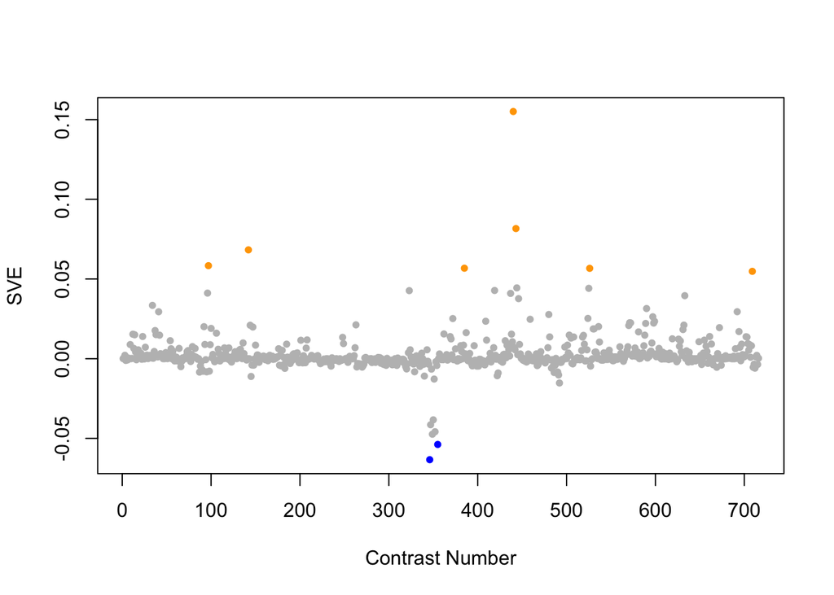

Positive SVE Contrasts:

|  | Contrast.Num | SVE | GEO.GSE | Cond.1 | Cond.2 | Mutation |
| --- | --- | --- | --- | --- | --- | --- |
| GSE27677B.s1t2.vs.s1t1 | 440 | 0.16 | GSE27677 | N2, Fast 3 h, rep 1 | N2, Fed 0 h, rep 1 |  |
| GSE27677B.s1t3.vs.s1t1 | 443 | 0.08 | GSE27677 | N2, Fast 6 h, rep 1 | N2, Fed 0 h, rep 1 |  |
| GSE50513.s2t1.vs.s1t1 | 142 | 0.07 | GSE50513 | L4440 PA14 - rep 1 | L4440 OP50 - rep 1 |  |
| GSE5793.s3t1.vs.s2t1 | 97 | 0.06 | GSE5793 | Celegans_PA14_4hours_RepA | Celegans_OP50_4hours_RepA |  |
| GSE34026.s3t1.vs.s0t1 | 385 | 0.06 | GSE34026 | N2 exposed to CVD110, biological rep1 | N2 exposed to OP50(E.coli), biological rep1 |  |
| GSE2180.s4t8.vs.s3t8 | 526 | 0.06 | GSE2180 | pp122-1 | p122-2 | pal-1(RNAi) |
| GSE11055.s2t3.vs.s2t2 | 709 | 0.05 | GSE11055 | L1 larvae 1 hr after hatching in the absence of food | L1 larvae 0 hr after hatching in the absence of food |  |

Negative SVE Contrasts:

|  | Contrast.Num | SVE | GEO.GSE | Cond.1 | Cond.2 | Mutation |
| --- | --- | --- | --- | --- | --- | --- |
| GSE38997.s1t2.vs.s1t1 | 346 | -0.06 | GSE38997 | experiment 4 control samples at 24 h 4c24 | experiment 4 control samples at 3 h 4c3 |  |
| GSE38997.s4t2.vs.s4t1 | 355 | -0.05 | GSE38997 | experiment 4 UVC-exposed samples at 24 h 4u24 | experiment 4 UVC-exposed samples at 3 h 4u3 |  |
| GSE38997.s2t2.vs.s2t1 | 349 | -0.05 | GSE38997 | experiment 4 EtBr-exposed samples at 24 h 4e24 | experiment 4 EtBr-exposed samples at 3 h 4e3 |  |
| GSE38997.s3t2.vs.s3t1 | 352 | -0.05 | GSE38997 | experiment 4 UVC- and EtBr-exposed samples at 24 h 4eu24 | experiment 4 UVC- and EtBr-exposed samples at 3 h 4eu3 |  |
| GSE38997.s2t3.vs.s2t1 | 347 | -0.04 | GSE38997 | experiment 1 EtBr-exposed samples at 48 h 1e48 | experiment 4 EtBr-exposed samples at 3 h 4e3 |  |

$~$

#### Contrast SVE, Down-Regulated Genes Only:

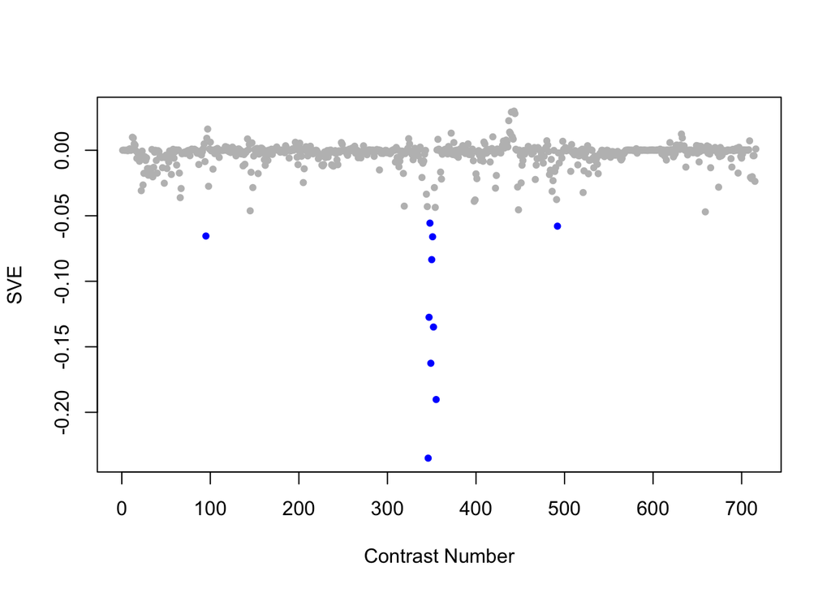

Positive SVE Contrasts:

|  | Contrast.Num | SVE | GEO.GSE | Cond.1 | Cond.2 | Mutation |
| --- | --- | --- | --- | --- | --- | --- |
| GSE27677B.s1t3.vs.s1t1 | 443 | 0.03 | GSE27677 | N2, Fast 6 h, rep 1 | N2, Fed 0 h, rep 1 |  |
| GSE27677B.s1t2.vs.s1t1 | 440 | 0.03 | GSE27677 | N2, Fast 3 h, rep 1 | N2, Fed 0 h, rep 1 |  |
| GSE27677B.s1t4.vs.s1t1 | 444 | 0.03 | GSE27677 | N2, Fast 9 h, rep 1 | N2, Fed 0 h, rep 1 |  |
| GSE27677B.s1t5.vs.s1t1 | 437 | 0.02 | GSE27677 | N2, Fast 12 h, rep 1 | N2, Fed 0 h, rep 1 |  |
| GSE5793.s3t1.vs.s2t1 | 97 | 0.02 | GSE5793 | Celegans_PA14_4hours_RepA | Celegans_OP50_4hours_RepA |  |

Negative SVE Contrasts:

|  | Contrast.Num | SVE | GEO.GSE | Cond.1 | Cond.2 | Mutation |
| --- | --- | --- | --- | --- | --- | --- |
| GSE38997.s1t2.vs.s1t1 | 346 | -0.23 | GSE38997 | experiment 4 control samples at 24 h 4c24 | experiment 4 control samples at 3 h 4c3 |  |
| GSE38997.s4t2.vs.s4t1 | 355 | -0.19 | GSE38997 | experiment 4 UVC-exposed samples at 24 h 4u24 | experiment 4 UVC-exposed samples at 3 h 4u3 |  |
| GSE38997.s2t2.vs.s2t1 | 349 | -0.16 | GSE38997 | experiment 4 EtBr-exposed samples at 24 h 4e24 | experiment 4 EtBr-exposed samples at 3 h 4e3 |  |
| GSE38997.s3t2.vs.s3t1 | 352 | -0.13 | GSE38997 | experiment 4 UVC- and EtBr-exposed samples at 24 h 4eu24 | experiment 4 UVC- and EtBr-exposed samples at 3 h 4eu3 |  |
| GSE38997.s2t3.vs.s2t1 | 347 | -0.13 | GSE38997 | experiment 1 EtBr-exposed samples at 48 h 1e48 | experiment 4 EtBr-exposed samples at 3 h 4e3 |  |
| GSE38997.s3t3.vs.s3t1 | 350 | -0.08 | GSE38997 | experiment 1 UVC- and EtBr-exposed samples at 48 h 1eu48 | experiment 4 UVC- and EtBr-exposed samples at 3 h 4eu3 |  |
| GSE38997.s3t4.vs.s3t1 | 351 | -0.07 | GSE38997 | experiment 1 UVC- and EtBr-exposed samples at 51 h 1eu51 | experiment 4 UVC- and EtBr-exposed samples at 3 h 4eu3 |  |
| GSE5793.s2t1.vs.s1t1 | 95 | -0.07 | GSE5793 | Celegans_OP50_4hours_RepA | Celegans_gacA_4hours_RepA |  |
| GSE23528B.s1t6.vs.s1t1 | 492 | -0.06 | GSE23528 | Adult at T46 in CC, time-series experiment 3 | Adult at T26 in CC, time-series experiment 3 |  |
| GSE38997.s2t4.vs.s2t1 | 348 | -0.06 | GSE38997 | experiment 1 EtBr-exposed samples at 51 h 1e51 | experiment 4 EtBr-exposed samples at 3 h 4e3 |  |

$~$

$~$

#### GO Term Enrichment:

This analysis tests each hemi-module for enrichment of specific GO terms. Only gene-level annotations (e.g., as would be found on the gene’s page in Wormbase) are tested - the hierarchical structure of the GO ontology is not taken into account.

*Note: At least the top two most enriched terms from each GO domain (BP/MF/CC) are shown, even when not statistically significant.*

##### Enriched GO terms: Hemi-module A

| ID | GO.Term | GO Domain | Raw p-value | Adj p-value |
| --- | --- | --- | --- | --- |
| [GO_0055114](http://amigo.geneontology.org/amigo/term/GO:0055114) | oxidation-reduction process | BP | 1.86e-42 | 6.77e-39 |
| [GO_0006635](http://amigo.geneontology.org/amigo/term/GO:0006635) | fatty acid beta-oxidation | BP | 4.79e-23 | 8.73e-20 |
| [GO_0006631](http://amigo.geneontology.org/amigo/term/GO:0006631) | fatty acid metabolic process | BP | 2.81e-15 | 3.41e-12 |
| [GO_0006637](http://amigo.geneontology.org/amigo/term/GO:0006637) | acyl-CoA metabolic process | BP | 5.13e-12 | 3.81e-09 |
| [GO_0009437](http://amigo.geneontology.org/amigo/term/GO:0009437) | carnitine metabolic process | BP | 5.23e-12 | 3.81e-09 |
| [GO_0007031](http://amigo.geneontology.org/amigo/term/GO:0007031) | peroxisome organization | BP | 2.39e-09 | 1.25e-06 |
| [GO_0016558](http://amigo.geneontology.org/amigo/term/GO:0016558) | protein import into peroxisome matrix | BP | 2.39e-09 | 1.25e-06 |
| [GO_1904070](http://amigo.geneontology.org/amigo/term/GO:1904070) | ascaroside biosynthetic process | BP | 3.09e-08 | 1.41e-05 |
| [GO_0033540](http://amigo.geneontology.org/amigo/term/GO:0033540) | fatty acid beta-oxidation using acyl-CoA oxidase | BP | 1.53e-07 | 6.19e-05 |
| [GO_0006625](http://amigo.geneontology.org/amigo/term/GO:0006625) | protein targeting to peroxisome | BP | 4.54e-07 | 1.58e-04 |
| [GO_0009062](http://amigo.geneontology.org/amigo/term/GO:0009062) | fatty acid catabolic process | BP | 4.76e-07 | 1.58e-04 |
| [GO_0055088](http://amigo.geneontology.org/amigo/term/GO:0055088) | lipid homeostasis | BP | 3.76e-05 | 1.14e-02 |
| [GO_0008652](http://amigo.geneontology.org/amigo/term/GO:0008652) | cellular amino acid biosynthetic process | BP | 8.16e-05 | 2.29e-02 |
| [GO_0000038](http://amigo.geneontology.org/amigo/term/GO:0000038) | very long-chain fatty acid metabolic process | BP | 1.78e-04 | 4.32e-02 |
| [GO_0045329](http://amigo.geneontology.org/amigo/term/GO:0045329) | carnitine biosynthetic process | BP | 1.78e-04 | 4.32e-02 |
| [GO_0044255](http://amigo.geneontology.org/amigo/term/GO:0044255) | cellular lipid metabolic process | BP | 2.63e-04 | 6.00e-02 |
| [GO_0001561](http://amigo.geneontology.org/amigo/term/GO:0001561) | fatty acid alpha-oxidation | BP | 5.29e-04 | 9.64e-02 |
| [GO_0016560](http://amigo.geneontology.org/amigo/term/GO:0016560) | protein import into peroxisome matrix, docking | BP | 5.29e-04 | 9.64e-02 |
| [GO_0042811](http://amigo.geneontology.org/amigo/term/GO:0042811) | pheromone biosynthetic process | BP | 5.29e-04 | 9.64e-02 |
| [GO_0048639](http://amigo.geneontology.org/amigo/term/GO:0048639) | positive regulation of developmental growth | BP | 5.29e-04 | 9.64e-02 |
| [GO_0016491](http://amigo.geneontology.org/amigo/term/GO:0016491) | oxidoreductase activity | MF | 2.04e-34 | 4.16e-31 |
| [GO_0004095](http://amigo.geneontology.org/amigo/term/GO:0004095) | carnitine O-palmitoyltransferase activity | MF | 6.74e-14 | 6.89e-11 |
| [GO_0003824](http://amigo.geneontology.org/amigo/term/GO:0003824) | catalytic activity | MF | 2.33e-12 | 1.59e-09 |
| [GO_0016627](http://amigo.geneontology.org/amigo/term/GO:0016627) | oxidoreductase activity, acting on the CH-CH group of donors | MF | 4.84e-12 | 2.47e-09 |
| [GO_0050660](http://amigo.geneontology.org/amigo/term/GO:0050660) | flavin adenine dinucleotide binding | MF | 1.42e-11 | 5.80e-09 |
| [GO_0005506](http://amigo.geneontology.org/amigo/term/GO:0005506) | iron ion binding | MF | 2.10e-11 | 7.14e-09 |
| [GO_0004497](http://amigo.geneontology.org/amigo/term/GO:0004497) | monooxygenase activity | MF | 2.13e-09 | 6.22e-07 |
| [GO_0016746](http://amigo.geneontology.org/amigo/term/GO:0016746) | transferase activity, transferring acyl groups | MF | 5.46e-09 | 1.39e-06 |
| [GO_0005504](http://amigo.geneontology.org/amigo/term/GO:0005504) | fatty acid binding | MF | 8.29e-09 | 1.88e-06 |
| [GO_0047617](http://amigo.geneontology.org/amigo/term/GO:0047617) | acyl-CoA hydrolase activity | MF | 1.44e-08 | 2.94e-06 |
| [GO_0003857](http://amigo.geneontology.org/amigo/term/GO:0003857) | 3-hydroxyacyl-CoA dehydrogenase activity | MF | 2.19e-08 | 4.06e-06 |
| [GO_0016705](http://amigo.geneontology.org/amigo/term/GO:0016705) | oxidoreductase activity, acting on paired donors, with incorporation or reduction of molecular oxygen | MF | 1.02e-07 | 1.74e-05 |
| [GO_0003997](http://amigo.geneontology.org/amigo/term/GO:0003997) | acyl-CoA oxidase activity | MF | 1.53e-07 | 2.40e-05 |
| [GO_0020037](http://amigo.geneontology.org/amigo/term/GO:0020037) | heme binding | MF | 4.58e-07 | 6.68e-05 |
| [GO_0004300](http://amigo.geneontology.org/amigo/term/GO:0004300) | enoyl-CoA hydratase activity | MF | 1.05e-06 | 1.43e-04 |
| [GO_0016509](http://amigo.geneontology.org/amigo/term/GO:0016509) | long-chain-3-hydroxyacyl-CoA dehydrogenase activity | MF | 2.35e-06 | 3.00e-04 |
| [GO_0071949](http://amigo.geneontology.org/amigo/term/GO:0071949) | FAD binding | MF | 4.03e-06 | 4.84e-04 |
| [GO_0004022](http://amigo.geneontology.org/amigo/term/GO:0004022) | alcohol dehydrogenase (NAD) activity | MF | 4.57e-05 | 5.18e-03 |
| [GO_0004499](http://amigo.geneontology.org/amigo/term/GO:0004499) | N,N-dimethylaniline monooxygenase activity | MF | 7.91e-05 | 8.34e-03 |
| [GO_0050661](http://amigo.geneontology.org/amigo/term/GO:0050661) | NADP binding | MF | 8.16e-05 | 8.34e-03 |
| [GO_0004096](http://amigo.geneontology.org/amigo/term/GO:0004096) | catalase activity | MF | 1.78e-04 | 1.58e-02 |
| [GO_0016508](http://amigo.geneontology.org/amigo/term/GO:0016508) | long-chain-enoyl-CoA hydratase activity | MF | 1.78e-04 | 1.58e-02 |
| [GO_0051750](http://amigo.geneontology.org/amigo/term/GO:0051750) | delta3,5-delta2,4-dienoyl-CoA isomerase activity | MF | 1.78e-04 | 1.58e-02 |
| [GO_0016616](http://amigo.geneontology.org/amigo/term/GO:0016616) | oxidoreductase activity, acting on the CH-OH group of donors, NAD or NADP as acceptor | MF | 1.87e-04 | 1.59e-02 |
| [GO_0000062](http://amigo.geneontology.org/amigo/term/GO:0000062) | fatty-acyl-CoA binding | MF | 3.59e-04 | 2.93e-02 |
| [GO_0003988](http://amigo.geneontology.org/amigo/term/GO:0003988) | acetyl-CoA C-acyltransferase activity | MF | 1.05e-03 | 7.65e-02 |
| [GO_0004301](http://amigo.geneontology.org/amigo/term/GO:0004301) | epoxide hydrolase activity | MF | 1.05e-03 | 7.65e-02 |
| [GO_0005324](http://amigo.geneontology.org/amigo/term/GO:0005324) | long-chain fatty acid transporter activity | MF | 1.05e-03 | 7.65e-02 |
| [GO_0016620](http://amigo.geneontology.org/amigo/term/GO:0016620) | oxidoreductase activity, acting on the aldehyde or oxo group of donors, NAD or NADP as acceptor | MF | 1.16e-03 | 8.16e-02 |
| [GO_0016747](http://amigo.geneontology.org/amigo/term/GO:0016747) | transferase activity, transferring acyl groups other than amino-acyl groups | MF | 1.22e-03 | 8.28e-02 |
| [GO_0005777](http://amigo.geneontology.org/amigo/term/GO:0005777) | peroxisome | CC | 5.59e-28 | 5.19e-25 |
| [GO_0005778](http://amigo.geneontology.org/amigo/term/GO:0005778) | peroxisomal membrane | CC | 1.05e-12 | 4.87e-10 |
| [GO_0005739](http://amigo.geneontology.org/amigo/term/GO:0005739) | mitochondrion | CC | 6.04e-12 | 1.87e-09 |
| [GO_0005782](http://amigo.geneontology.org/amigo/term/GO:0005782) | peroxisomal matrix | CC | 2.13e-11 | 4.93e-09 |
| [GO_0005634](http://amigo.geneontology.org/amigo/term/GO:0005634) | nucleus | CC | 7.88e-07 | 1.46e-04 |
| [GO_0016020](http://amigo.geneontology.org/amigo/term/GO:0016020) | membrane | CC | 1.96e-05 | 3.03e-03 |
| [GO_0005779](http://amigo.geneontology.org/amigo/term/GO:0005779) | integral component of peroxisomal membrane | CC | 2.31e-05 | 3.06e-03 |
| [GO_0016021](http://amigo.geneontology.org/amigo/term/GO:0016021) | integral component of membrane | CC | 7.06e-05 | 8.19e-03 |
| [GO_0005811](http://amigo.geneontology.org/amigo/term/GO:0005811) | lipid droplet | CC | 8.16e-05 | 8.42e-03 |
| [GO_0016507](http://amigo.geneontology.org/amigo/term/GO:0016507) | mitochondrial fatty acid beta-oxidation multienzyme complex | CC | 1.78e-04 | 1.54e-02 |
| [GO_0043231](http://amigo.geneontology.org/amigo/term/GO:0043231) | intracellular membrane-bounded organelle | CC | 1.83e-04 | 1.54e-02 |
| [GO_0005886](http://amigo.geneontology.org/amigo/term/GO:0005886) | plasma membrane | CC | 3.27e-04 | 2.53e-02 |
| [GO_1990429](http://amigo.geneontology.org/amigo/term/GO:1990429) | peroxisomal importomer complex | CC | 5.29e-04 | 3.78e-02 |
| [GO_0031090](http://amigo.geneontology.org/amigo/term/GO:0031090) | organelle membrane | CC | 6.09e-04 | 4.04e-02 |
| [GO_0005887](http://amigo.geneontology.org/amigo/term/GO:0005887) | integral component of plasma membrane | CC | 8.44e-04 | 5.22e-02 |

##### Enriched GO terms: Hemi-module B

| ID | GO.Term | GO Domain | Raw p-value | Adj p-value |
| --- | --- | --- | --- | --- |
| [GO_0036498](http://amigo.geneontology.org/amigo/term/GO:0036498) | IRE1-mediated unfolded protein response | BP | 6.48e-04 | 1.00e+00 |
| [GO_0008209](http://amigo.geneontology.org/amigo/term/GO:0008209) | androgen metabolic process | BP | 1.58e-03 | 1.00e+00 |
| [GO_0016298](http://amigo.geneontology.org/amigo/term/GO:0016298) | lipase activity | MF | 3.98e-04 | 4.61e-01 |
| [GO_0030283](http://amigo.geneontology.org/amigo/term/GO:0030283) | testosterone dehydrogenase [NAD(P)] activity | MF | 1.58e-03 | 4.61e-01 |
| [GO_0005739](http://amigo.geneontology.org/amigo/term/GO:0005739) | mitochondrion | CC | 5.93e-03 | 1.00e+00 |
| [GO_0005751](http://amigo.geneontology.org/amigo/term/GO:0005751) | mitochondrial respiratory chain complex IV | CC | 7.87e-03 | 1.00e+00 |

$~$

$~$

#### Tissue Enrichment:

This analysis tests each hemi-module for enrichment of genes associated with anatomy terms. Negative enrichment scores indicate fewer hemi-module genes than expected by random chance were associated with the anatomy term in question.

##### Enriched tissues: Hemi-module A

| ID | Anatomy.Term | Definition | Raw p-value | Adj p-value |
| --- | --- | --- | --- | --- |
| [WBbt_0005772](https://wormbase.org/species/all/anatomy_term/WBbt:0005772) | intestine | A chain of very large cuboidal cells forming a wide central lumen in which food arrives from the posterior pharynx, is digested, and from which waste products proceed to the rectum. Intestinal rings f… | 2.65e-15 | 6.45e-12 |
| [WBbt_0005733](https://wormbase.org/species/all/anatomy_term/WBbt:0005733) | hypodermis | Epidermal layer. | 4.48e-05 | 5.44e-02 |

##### Enriched tissues: Hemi-module B

No significant annotations.

$~$

$~$

#### HOMER promoter motif enrichment:

This analysis tests each hemi-module for enrichment of 108 known *C. elegans* transcription factor binding site motifs (see [108 CE motifs](https://katiepod.github.io//all.worm.motifs.html)) using the HOMER (Hypergeometric Optimization of Motif EnRichment) software (see [PMID:20513432](https://pubmed.ncbi.nlm.nih.gov/20513432)). HOMER was run using default parameters on sequences 1 kb upstream of the transcription start site.

##### Motif enrichment: Hemi-module A

Total target sequences = 185  
Total background sequences = 40601  
* - possible false positive

Rank

Motif

P-value

log P-pvalue

% of Targets

% of Background

STD(Bg STD)

Best Match/Details

Motif File

1

[figure not shown]

1e-40

-9.267e+01

17.30%

0.39%

221.3bp (309.1bp)

POL008.1_DCE_S_I/Jaspar(0.417)  
[More Information](https://katiepod.github.io/HomerResults/m9_a_hemi_genes.txt.out.1kb/homerResults/motif1.info.html) | [Similar Motifs Found](https://katiepod.github.io/HomerResults/m9_a_hemi_genes.txt.out.1kb/homerResults/motif1.similar.html)

[motif file (matrix)](https://katiepod.github.io/HomerResults/m9_a_hemi_genes.txt.out.1kb/homerResults/motif1.motif)

2

[figure not shown]

1e-28

-6.598e+01

41.62%

9.89%

262.5bp (320.9bp)

POL008.1_DCE_S_I/Jaspar(0.539)  
[More Information](https://katiepod.github.io/HomerResults/m9_a_hemi_genes.txt.out.1kb/homerResults/motif2.info.html) | [Similar Motifs Found](https://katiepod.github.io/HomerResults/m9_a_hemi_genes.txt.out.1kb/homerResults/motif2.similar.html)

[motif file (matrix)](https://katiepod.github.io/HomerResults/m9_a_hemi_genes.txt.out.1kb/homerResults/motif2.motif)

3

[figure not shown]

1e-15

-3.479e+01

38.92%

14.67%

291.9bp (322.5bp)

PQM-1(?)/cElegans-L3-ChIP-Seq(modEncode)/Homer(0.931)  
[More Information](https://katiepod.github.io/HomerResults/m9_a_hemi_genes.txt.out.1kb/homerResults/motif3.info.html) | [Similar Motifs Found](https://katiepod.github.io/HomerResults/m9_a_hemi_genes.txt.out.1kb/homerResults/motif3.similar.html)

[motif file (matrix)](https://katiepod.github.io/HomerResults/m9_a_hemi_genes.txt.out.1kb/homerResults/motif3.motif)

4

[figure not shown]

1e-14

-3.283e+01

22.16%

5.27%

202.1bp (306.9bp)

eor-1/MA0543.1/Jaspar(0.776)  
[More Information](https://katiepod.github.io/HomerResults/m9_a_hemi_genes.txt.out.1kb/homerResults/motif4.info.html) | [Similar Motifs Found](https://katiepod.github.io/HomerResults/m9_a_hemi_genes.txt.out.1kb/homerResults/motif4.similar.html)

[motif file (matrix)](https://katiepod.github.io/HomerResults/m9_a_hemi_genes.txt.out.1kb/homerResults/motif4.motif)

5

[figure not shown]

1e-14

-3.224e+01

10.81%

1.00%

302.4bp (303.0bp)

MF0004.1_Nuclear_Receptor_class/Jaspar(0.622)  
[More Information](https://katiepod.github.io/HomerResults/m9_a_hemi_genes.txt.out.1kb/homerResults/motif5.info.html) | [Similar Motifs Found](https://katiepod.github.io/HomerResults/m9_a_hemi_genes.txt.out.1kb/homerResults/motif5.similar.html)

[motif file (matrix)](https://katiepod.github.io/HomerResults/m9_a_hemi_genes.txt.out.1kb/homerResults/motif5.motif)

6

[figure not shown]

1e-12

-2.955e+01

13.51%

2.03%

274.3bp (320.2bp)

elt-2/MA1701.1/Jaspar(0.615)  
[More Information](https://katiepod.github.io/HomerResults/m9_a_hemi_genes.txt.out.1kb/homerResults/motif6.info.html) | [Similar Motifs Found](https://katiepod.github.io/HomerResults/m9_a_hemi_genes.txt.out.1kb/homerResults/motif6.similar.html)

[motif file (matrix)](https://katiepod.github.io/HomerResults/m9_a_hemi_genes.txt.out.1kb/homerResults/motif6.motif)

7

[figure not shown]

1e-12

-2.871e+01

15.14%

2.72%

273.7bp (324.4bp)

ceh-22/MA0264.1/Jaspar(0.520)  
[More Information](https://katiepod.github.io/HomerResults/m9_a_hemi_genes.txt.out.1kb/homerResults/motif7.info.html) | [Similar Motifs Found](https://katiepod.github.io/HomerResults/m9_a_hemi_genes.txt.out.1kb/homerResults/motif7.similar.html)

[motif file (matrix)](https://katiepod.github.io/HomerResults/m9_a_hemi_genes.txt.out.1kb/homerResults/motif7.motif)

8 *

[figure not shown]

1e-11

-2.686e+01

10.81%

1.36%

280.3bp (308.1bp)

ceh-10::ttx-3/MA0263.1/Jaspar(0.579)  
[More Information](https://katiepod.github.io/HomerResults/m9_a_hemi_genes.txt.out.1kb/homerResults/motif8.info.html) | [Similar Motifs Found](https://katiepod.github.io/HomerResults/m9_a_hemi_genes.txt.out.1kb/homerResults/motif8.similar.html)

[motif file (matrix)](https://katiepod.github.io/HomerResults/m9_a_hemi_genes.txt.out.1kb/homerResults/motif8.motif)

9 *

[figure not shown]

1e-11

-2.611e+01

7.57%

0.54%

252.0bp (340.8bp)

MF0004.1_Nuclear_Receptor_class/Jaspar(0.644)  
[More Information](https://katiepod.github.io/HomerResults/m9_a_hemi_genes.txt.out.1kb/homerResults/motif9.info.html) | [Similar Motifs Found](https://katiepod.github.io/HomerResults/m9_a_hemi_genes.txt.out.1kb/homerResults/motif9.similar.html)

[motif file (matrix)](https://katiepod.github.io/HomerResults/m9_a_hemi_genes.txt.out.1kb/homerResults/motif9.motif)

10 *

[figure not shown]

1e-10

-2.336e+01

7.03%

0.55%

304.7bp (313.9bp)

MF0010.1_Homeobox_class/Jaspar(0.635)  
[More Information](https://katiepod.github.io/HomerResults/m9_a_hemi_genes.txt.out.1kb/homerResults/motif10.info.html) | [Similar Motifs Found](https://katiepod.github.io/HomerResults/m9_a_hemi_genes.txt.out.1kb/homerResults/motif10.similar.html)

[motif file (matrix)](https://katiepod.github.io/HomerResults/m9_a_hemi_genes.txt.out.1kb/homerResults/motif10.motif)

11 *

[figure not shown]

1e-9

-2.232e+01

21.62%

7.05%

279.7bp (314.9bp)

LIN-39(Homeobox)/cElegans.L3-LIN39-ChIP-Seq(modEncode)/Homer(0.672)  
[More Information](https://katiepod.github.io/HomerResults/m9_a_hemi_genes.txt.out.1kb/homerResults/motif11.info.html) | [Similar Motifs Found](https://katiepod.github.io/HomerResults/m9_a_hemi_genes.txt.out.1kb/homerResults/motif11.similar.html)

[motif file (matrix)](https://katiepod.github.io/HomerResults/m9_a_hemi_genes.txt.out.1kb/homerResults/motif11.motif)

12 *

[figure not shown]

1e-9

-2.186e+01

12.97%

2.69%

265.7bp (326.2bp)

POL012.1_TATA-Box/Jaspar(0.776)  
[More Information](https://katiepod.github.io/HomerResults/m9_a_hemi_genes.txt.out.1kb/homerResults/motif12.info.html) | [Similar Motifs Found](https://katiepod.github.io/HomerResults/m9_a_hemi_genes.txt.out.1kb/homerResults/motif12.similar.html)

[motif file (matrix)](https://katiepod.github.io/HomerResults/m9_a_hemi_genes.txt.out.1kb/homerResults/motif12.motif)

13 *

[figure not shown]

1e-9

-2.176e+01

6.49%

0.50%

285.5bp (309.6bp)

blmp-1/MA0537.1/Jaspar(0.506)  
[More Information](https://katiepod.github.io/HomerResults/m9_a_hemi_genes.txt.out.1kb/homerResults/motif13.info.html) | [Similar Motifs Found](https://katiepod.github.io/HomerResults/m9_a_hemi_genes.txt.out.1kb/homerResults/motif13.similar.html)

[motif file (matrix)](https://katiepod.github.io/HomerResults/m9_a_hemi_genes.txt.out.1kb/homerResults/motif13.motif)

14 *

[figure not shown]

1e-8

-1.926e+01

30.81%

14.03%

302.5bp (309.6bp)

fkh-9/MA1440.1/Jaspar(0.593)  
[More Information](https://katiepod.github.io/HomerResults/m9_a_hemi_genes.txt.out.1kb/homerResults/motif14.info.html) | [Similar Motifs Found](https://katiepod.github.io/HomerResults/m9_a_hemi_genes.txt.out.1kb/homerResults/motif14.similar.html)

[motif file (matrix)](https://katiepod.github.io/HomerResults/m9_a_hemi_genes.txt.out.1kb/homerResults/motif14.motif)

15 *

[figure not shown]

1e-8

-1.874e+01

10.27%

1.96%

305.2bp (331.9bp)

unc-30/MA1443.1/Jaspar(0.537)  
[More Information](https://katiepod.github.io/HomerResults/m9_a_hemi_genes.txt.out.1kb/homerResults/motif15.info.html) | [Similar Motifs Found](https://katiepod.github.io/HomerResults/m9_a_hemi_genes.txt.out.1kb/homerResults/motif15.similar.html)

[motif file (matrix)](https://katiepod.github.io/HomerResults/m9_a_hemi_genes.txt.out.1kb/homerResults/motif15.motif)

16 *

[figure not shown]

1e-7

-1.753e+01

3.78%

0.15%

239.3bp (307.6bp)

ceh-22/MA0264.1/Jaspar(0.564)  
[More Information](https://katiepod.github.io/HomerResults/m9_a_hemi_genes.txt.out.1kb/homerResults/motif16.info.html) | [Similar Motifs Found](https://katiepod.github.io/HomerResults/m9_a_hemi_genes.txt.out.1kb/homerResults/motif16.similar.html)

[motif file (matrix)](https://katiepod.github.io/HomerResults/m9_a_hemi_genes.txt.out.1kb/homerResults/motif16.motif)

17 *

[figure not shown]

1e-7

-1.637e+01

8.65%

1.60%

310.5bp (315.4bp)

PL0011.1_hlh-2::hlh-4/Jaspar(0.654)  
[More Information](https://katiepod.github.io/HomerResults/m9_a_hemi_genes.txt.out.1kb/homerResults/motif17.info.html) | [Similar Motifs Found](https://katiepod.github.io/HomerResults/m9_a_hemi_genes.txt.out.1kb/homerResults/motif17.similar.html)

[motif file (matrix)](https://katiepod.github.io/HomerResults/m9_a_hemi_genes.txt.out.1kb/homerResults/motif17.motif)

18 *

[figure not shown]

1e-6

-1.584e+01

2.16%

0.02%

248.4bp (232.2bp)

DPL-1(E2F)/cElegans-Adult-ChIP-Seq(modEncode)/Homer(0.567)  
[More Information](https://katiepod.github.io/HomerResults/m9_a_hemi_genes.txt.out.1kb/homerResults/motif18.info.html) | [Similar Motifs Found](https://katiepod.github.io/HomerResults/m9_a_hemi_genes.txt.out.1kb/homerResults/motif18.similar.html)

[motif file (matrix)](https://katiepod.github.io/HomerResults/m9_a_hemi_genes.txt.out.1kb/homerResults/motif18.motif)

19 *

[figure not shown]

1e-6

-1.481e+01

5.41%

0.62%

232.7bp (325.7bp)

PL0012.1_hlh-2::hlh-8/Jaspar(0.563)  
[More Information](https://katiepod.github.io/HomerResults/m9_a_hemi_genes.txt.out.1kb/homerResults/motif19.info.html) | [Similar Motifs Found](https://katiepod.github.io/HomerResults/m9_a_hemi_genes.txt.out.1kb/homerResults/motif19.similar.html)

[motif file (matrix)](https://katiepod.github.io/HomerResults/m9_a_hemi_genes.txt.out.1kb/homerResults/motif19.motif)

20 *

[figure not shown]

1e-6

-1.420e+01

10.81%

2.92%

294.6bp (312.4bp)

LIN-39(Homeobox)/cElegans.L3-LIN39-ChIP-Seq(modEncode)/Homer(0.624)  
[More Information](https://katiepod.github.io/HomerResults/m9_a_hemi_genes.txt.out.1kb/homerResults/motif20.info.html) | [Similar Motifs Found](https://katiepod.github.io/HomerResults/m9_a_hemi_genes.txt.out.1kb/homerResults/motif20.similar.html)

[motif file (matrix)](https://katiepod.github.io/HomerResults/m9_a_hemi_genes.txt.out.1kb/homerResults/motif20.motif)

21 *

[figure not shown]

1e-6

-1.389e+01

2.70%

0.08%

349.2bp (322.9bp)

zip-8/MA1704.1/Jaspar(0.833)  
[More Information](https://katiepod.github.io/HomerResults/m9_a_hemi_genes.txt.out.1kb/homerResults/motif21.info.html) | [Similar Motifs Found](https://katiepod.github.io/HomerResults/m9_a_hemi_genes.txt.out.1kb/homerResults/motif21.similar.html)

[motif file (matrix)](https://katiepod.github.io/HomerResults/m9_a_hemi_genes.txt.out.1kb/homerResults/motif21.motif)

22 *

[figure not shown]

1e-5

-1.360e+01

21.08%

9.34%

269.1bp (321.5bp)

POL012.1_TATA-Box/Jaspar(0.467)  
[More Information](https://katiepod.github.io/HomerResults/m9_a_hemi_genes.txt.out.1kb/homerResults/motif22.info.html) | [Similar Motifs Found](https://katiepod.github.io/HomerResults/m9_a_hemi_genes.txt.out.1kb/homerResults/motif22.similar.html)

[motif file (matrix)](https://katiepod.github.io/HomerResults/m9_a_hemi_genes.txt.out.1kb/homerResults/motif22.motif)

23 *

[figure not shown]

1e-5

-1.284e+01

2.70%

0.11%

208.7bp (288.8bp)

SD0003.1_at_AC_acceptor/Jaspar(0.562)  
[More Information](https://katiepod.github.io/HomerResults/m9_a_hemi_genes.txt.out.1kb/homerResults/motif23.info.html) | [Similar Motifs Found](https://katiepod.github.io/HomerResults/m9_a_hemi_genes.txt.out.1kb/homerResults/motif23.similar.html)

[motif file (matrix)](https://katiepod.github.io/HomerResults/m9_a_hemi_genes.txt.out.1kb/homerResults/motif23.motif)

24 *

[figure not shown]

1e-5

-1.253e+01

4.86%

0.63%

257.6bp (306.6bp)

PL0002.1_hlh-2::hlh-3/Jaspar(0.643)  
[More Information](https://katiepod.github.io/HomerResults/m9_a_hemi_genes.txt.out.1kb/homerResults/motif24.info.html) | [Similar Motifs Found](https://katiepod.github.io/HomerResults/m9_a_hemi_genes.txt.out.1kb/homerResults/motif24.similar.html)

[motif file (matrix)](https://katiepod.github.io/HomerResults/m9_a_hemi_genes.txt.out.1kb/homerResults/motif24.motif)

25 *

[figure not shown]

1e-5

-1.253e+01

2.70%

0.11%

216.5bp (270.6bp)

PL0012.1_hlh-2::hlh-8/Jaspar(0.521)  
[More Information](https://katiepod.github.io/HomerResults/m9_a_hemi_genes.txt.out.1kb/homerResults/motif25.info.html) | [Similar Motifs Found](https://katiepod.github.io/HomerResults/m9_a_hemi_genes.txt.out.1kb/homerResults/motif25.similar.html)

[motif file (matrix)](https://katiepod.github.io/HomerResults/m9_a_hemi_genes.txt.out.1kb/homerResults/motif25.motif)

26 *

[figure not shown]

1e-5

-1.223e+01

5.41%

0.83%

129.7bp (302.7bp)

POL004.1_CCAAT-box/Jaspar(0.684)  
[More Information](https://katiepod.github.io/HomerResults/m9_a_hemi_genes.txt.out.1kb/homerResults/motif26.info.html) | [Similar Motifs Found](https://katiepod.github.io/HomerResults/m9_a_hemi_genes.txt.out.1kb/homerResults/motif26.similar.html)

[motif file (matrix)](https://katiepod.github.io/HomerResults/m9_a_hemi_genes.txt.out.1kb/homerResults/motif26.motif)

27 *

[figure not shown]

1e-5

-1.215e+01

2.70%

0.13%

317.7bp (304.2bp)

fkh-2/MA0920.1/Jaspar(0.507)  
[More Information](https://katiepod.github.io/HomerResults/m9_a_hemi_genes.txt.out.1kb/homerResults/motif27.info.html) | [Similar Motifs Found](https://katiepod.github.io/HomerResults/m9_a_hemi_genes.txt.out.1kb/homerResults/motif27.similar.html)

[motif file (matrix)](https://katiepod.github.io/HomerResults/m9_a_hemi_genes.txt.out.1kb/homerResults/motif27.motif)

28 *

[figure not shown]

1e-5

-1.205e+01

7.57%

1.74%

308.2bp (332.8bp)

elt-6/MA1439.1/Jaspar(0.554)  
[More Information](https://katiepod.github.io/HomerResults/m9_a_hemi_genes.txt.out.1kb/homerResults/motif28.info.html) | [Similar Motifs Found](https://katiepod.github.io/HomerResults/m9_a_hemi_genes.txt.out.1kb/homerResults/motif28.similar.html)

[motif file (matrix)](https://katiepod.github.io/HomerResults/m9_a_hemi_genes.txt.out.1kb/homerResults/motif28.motif)

29 *

[figure not shown]

1e-4

-9.701e+00

1.08%

0.00%

221.8bp (0.0bp)

SD0003.1_at_AC_acceptor/Jaspar(0.551)  
[More Information](https://katiepod.github.io/HomerResults/m9_a_hemi_genes.txt.out.1kb/homerResults/motif29.info.html) | [Similar Motifs Found](https://katiepod.github.io/HomerResults/m9_a_hemi_genes.txt.out.1kb/homerResults/motif29.similar.html)

[motif file (matrix)](https://katiepod.github.io/HomerResults/m9_a_hemi_genes.txt.out.1kb/homerResults/motif29.motif)

30 *

[figure not shown]

1e-3

-7.389e+00

4.86%

1.25%

244.7bp (262.2bp)

blmp-1/MA0537.1/Jaspar(0.520)  
[More Information](https://katiepod.github.io/HomerResults/m9_a_hemi_genes.txt.out.1kb/homerResults/motif30.info.html) | [Similar Motifs Found](https://katiepod.github.io/HomerResults/m9_a_hemi_genes.txt.out.1kb/homerResults/motif30.similar.html)

[motif file (matrix)](https://katiepod.github.io/HomerResults/m9_a_hemi_genes.txt.out.1kb/homerResults/motif30.motif)

31 *

[figure not shown]

1e-2

-5.905e+00

1.62%

0.14%

223.6bp (308.0bp)

lin-54/MA1450.1/Jaspar(0.650)  
[More Information](https://katiepod.github.io/HomerResults/m9_a_hemi_genes.txt.out.1kb/homerResults/motif31.info.html) | [Similar Motifs Found](https://katiepod.github.io/HomerResults/m9_a_hemi_genes.txt.out.1kb/homerResults/motif31.similar.html)

[motif file (matrix)](https://katiepod.github.io/HomerResults/m9_a_hemi_genes.txt.out.1kb/homerResults/motif31.motif)

32 *

[figure not shown]

1e-2

-5.501e+00

11.89%

6.41%

286.3bp (307.8bp)

POL003.1_GC-box/Jaspar(0.761)  
[More Information](https://katiepod.github.io/HomerResults/m9_a_hemi_genes.txt.out.1kb/homerResults/motif32.info.html) | [Similar Motifs Found](https://katiepod.github.io/HomerResults/m9_a_hemi_genes.txt.out.1kb/homerResults/motif32.similar.html)

[motif file (matrix)](https://katiepod.github.io/HomerResults/m9_a_hemi_genes.txt.out.1kb/homerResults/motif32.motif)

##### Motif enrichment: Hemi-module B

Total target sequences = 30  
Total background sequences = 37361  
* - possible false positive

Rank

Motif

P-value

log P-pvalue

% of Targets

% of Background

STD(Bg STD)

Best Match/Details

Motif File

1

[figure not shown]

1e-13

-3.197e+01

16.67%

0.01%

237.2bp (323.5bp)

MF0004.1_Nuclear_Receptor_class/Jaspar(0.559)  
[More Information](https://katiepod.github.io/HomerResults/m9_b_hemi_genes.txt.out.1kb/homerResults/motif1.info.html) | [Similar Motifs Found](https://katiepod.github.io/HomerResults/m9_b_hemi_genes.txt.out.1kb/homerResults/motif1.similar.html)

[motif file (matrix)](https://katiepod.github.io/HomerResults/m9_b_hemi_genes.txt.out.1kb/homerResults/motif1.motif)

2 *

[figure not shown]

1e-10

-2.383e+01

20.00%

0.20%

273.3bp (315.8bp)

mab-5/MA1442.1/Jaspar(0.585)  
[More Information](https://katiepod.github.io/HomerResults/m9_b_hemi_genes.txt.out.1kb/homerResults/motif2.info.html) | [Similar Motifs Found](https://katiepod.github.io/HomerResults/m9_b_hemi_genes.txt.out.1kb/homerResults/motif2.similar.html)

[motif file (matrix)](https://katiepod.github.io/HomerResults/m9_b_hemi_genes.txt.out.1kb/homerResults/motif2.motif)

3 *

[figure not shown]

1e-9

-2.248e+01

23.33%

0.51%

185.0bp (283.5bp)

POL007.1_BREd/Jaspar(0.565)  
[More Information](https://katiepod.github.io/HomerResults/m9_b_hemi_genes.txt.out.1kb/homerResults/motif3.info.html) | [Similar Motifs Found](https://katiepod.github.io/HomerResults/m9_b_hemi_genes.txt.out.1kb/homerResults/motif3.similar.html)

[motif file (matrix)](https://katiepod.github.io/HomerResults/m9_b_hemi_genes.txt.out.1kb/homerResults/motif3.motif)

4 *

[figure not shown]

1e-9

-2.156e+01

16.67%

0.12%

222.3bp (310.0bp)

PL0003.1_hlh-2::cnd-1/Jaspar(0.551)  
[More Information](https://katiepod.github.io/HomerResults/m9_b_hemi_genes.txt.out.1kb/homerResults/motif4.info.html) | [Similar Motifs Found](https://katiepod.github.io/HomerResults/m9_b_hemi_genes.txt.out.1kb/homerResults/motif4.similar.html)

[motif file (matrix)](https://katiepod.github.io/HomerResults/m9_b_hemi_genes.txt.out.1kb/homerResults/motif4.motif)

5 *

[figure not shown]

1e-9

-2.125e+01

16.67%

0.13%

258.6bp (294.9bp)

elt-2/MA1701.1/Jaspar(0.610)  
[More Information](https://katiepod.github.io/HomerResults/m9_b_hemi_genes.txt.out.1kb/homerResults/motif5.info.html) | [Similar Motifs Found](https://katiepod.github.io/HomerResults/m9_b_hemi_genes.txt.out.1kb/homerResults/motif5.similar.html)

[motif file (matrix)](https://katiepod.github.io/HomerResults/m9_b_hemi_genes.txt.out.1kb/homerResults/motif5.motif)

6 *

[figure not shown]

1e-9

-2.121e+01

23.33%

0.61%

272.0bp (330.0bp)

ceh-28/MA1445.1/Jaspar(0.587)  
[More Information](https://katiepod.github.io/HomerResults/m9_b_hemi_genes.txt.out.1kb/homerResults/motif6.info.html) | [Similar Motifs Found](https://katiepod.github.io/HomerResults/m9_b_hemi_genes.txt.out.1kb/homerResults/motif6.similar.html)

[motif file (matrix)](https://katiepod.github.io/HomerResults/m9_b_hemi_genes.txt.out.1kb/homerResults/motif6.motif)

7 *

[figure not shown]

1e-9

-2.108e+01

30.00%

1.58%

247.7bp (309.3bp)

atf-7/MA1438.1/Jaspar(0.794)  
[More Information](https://katiepod.github.io/HomerResults/m9_b_hemi_genes.txt.out.1kb/homerResults/motif7.info.html) | [Similar Motifs Found](https://katiepod.github.io/HomerResults/m9_b_hemi_genes.txt.out.1kb/homerResults/motif7.similar.html)

[motif file (matrix)](https://katiepod.github.io/HomerResults/m9_b_hemi_genes.txt.out.1kb/homerResults/motif7.motif)

8 *

[figure not shown]

1e-9

-2.078e+01

16.67%

0.14%

412.8bp (297.9bp)

MF0005.1_Forkhead_class/Jaspar(0.602)  
[More Information](https://katiepod.github.io/HomerResults/m9_b_hemi_genes.txt.out.1kb/homerResults/motif8.info.html) | [Similar Motifs Found](https://katiepod.github.io/HomerResults/m9_b_hemi_genes.txt.out.1kb/homerResults/motif8.similar.html)

[motif file (matrix)](https://katiepod.github.io/HomerResults/m9_b_hemi_genes.txt.out.1kb/homerResults/motif8.motif)

9 *

[figure not shown]

1e-8

-2.033e+01

20.00%

0.37%

204.3bp (338.9bp)

elt-6/MA1439.1/Jaspar(0.855)  
[More Information](https://katiepod.github.io/HomerResults/m9_b_hemi_genes.txt.out.1kb/homerResults/motif9.info.html) | [Similar Motifs Found](https://katiepod.github.io/HomerResults/m9_b_hemi_genes.txt.out.1kb/homerResults/motif9.similar.html)

[motif file (matrix)](https://katiepod.github.io/HomerResults/m9_b_hemi_genes.txt.out.1kb/homerResults/motif9.motif)

10 *

[figure not shown]

1e-8

-2.026e+01

16.67%

0.16%

259.9bp (362.2bp)

ceh-48/MA0921.1/Jaspar(0.638)  
[More Information](https://katiepod.github.io/HomerResults/m9_b_hemi_genes.txt.out.1kb/homerResults/motif10.info.html) | [Similar Motifs Found](https://katiepod.github.io/HomerResults/m9_b_hemi_genes.txt.out.1kb/homerResults/motif10.similar.html)

[motif file (matrix)](https://katiepod.github.io/HomerResults/m9_b_hemi_genes.txt.out.1kb/homerResults/motif10.motif)

11 *

[figure not shown]

1e-8

-1.951e+01

16.67%

0.18%

267.7bp (293.7bp)

MF0011.1_HMG_class/Jaspar(0.627)  
[More Information](https://katiepod.github.io/HomerResults/m9_b_hemi_genes.txt.out.1kb/homerResults/motif11.info.html) | [Similar Motifs Found](https://katiepod.github.io/HomerResults/m9_b_hemi_genes.txt.out.1kb/homerResults/motif11.similar.html)

[motif file (matrix)](https://katiepod.github.io/HomerResults/m9_b_hemi_genes.txt.out.1kb/homerResults/motif11.motif)

12 *

[figure not shown]

1e-8

-1.852e+01

13.33%

0.07%

439.9bp (383.7bp)

ceh-48/MA0921.1/Jaspar(0.640)  
[More Information](https://katiepod.github.io/HomerResults/m9_b_hemi_genes.txt.out.1kb/homerResults/motif12.info.html) | [Similar Motifs Found](https://katiepod.github.io/HomerResults/m9_b_hemi_genes.txt.out.1kb/homerResults/motif12.similar.html)

[motif file (matrix)](https://katiepod.github.io/HomerResults/m9_b_hemi_genes.txt.out.1kb/homerResults/motif12.motif)

13 *

[figure not shown]

1e-7

-1.825e+01

33.33%

3.04%

259.3bp (322.5bp)

SD0001.1_at_AC_acceptor/Jaspar(0.700)  
[More Information](https://katiepod.github.io/HomerResults/m9_b_hemi_genes.txt.out.1kb/homerResults/motif13.info.html) | [Similar Motifs Found](https://katiepod.github.io/HomerResults/m9_b_hemi_genes.txt.out.1kb/homerResults/motif13.similar.html)

[motif file (matrix)](https://katiepod.github.io/HomerResults/m9_b_hemi_genes.txt.out.1kb/homerResults/motif13.motif)

14 *

[figure not shown]

1e-7

-1.811e+01

30.00%

2.24%

294.9bp (303.0bp)

PL0004.1_hlh-27/Jaspar(0.588)  
[More Information](https://katiepod.github.io/HomerResults/m9_b_hemi_genes.txt.out.1kb/homerResults/motif14.info.html) | [Similar Motifs Found](https://katiepod.github.io/HomerResults/m9_b_hemi_genes.txt.out.1kb/homerResults/motif14.similar.html)

[motif file (matrix)](https://katiepod.github.io/HomerResults/m9_b_hemi_genes.txt.out.1kb/homerResults/motif14.motif)

15 *

[figure not shown]

1e-7

-1.640e+01

13.33%

0.13%

405.5bp (266.3bp)

fkh-9/MA1440.1/Jaspar(0.625)  
[More Information](https://katiepod.github.io/HomerResults/m9_b_hemi_genes.txt.out.1kb/homerResults/motif15.info.html) | [Similar Motifs Found](https://katiepod.github.io/HomerResults/m9_b_hemi_genes.txt.out.1kb/homerResults/motif15.similar.html)

[motif file (matrix)](https://katiepod.github.io/HomerResults/m9_b_hemi_genes.txt.out.1kb/homerResults/motif15.motif)

16 *

[figure not shown]

1e-6

-1.610e+01

10.00%

0.03%

336.6bp (288.4bp)

MF0002.1_bZIP_CREB/G-box-like_subclass/Jaspar(0.742)  
[More Information](https://katiepod.github.io/HomerResults/m9_b_hemi_genes.txt.out.1kb/homerResults/motif16.info.html) | [Similar Motifs Found](https://katiepod.github.io/HomerResults/m9_b_hemi_genes.txt.out.1kb/homerResults/motif16.similar.html)

[motif file (matrix)](https://katiepod.github.io/HomerResults/m9_b_hemi_genes.txt.out.1kb/homerResults/motif16.motif)

17 *

[figure not shown]

1e-6

-1.558e+01

30.00%

3.02%

244.6bp (311.4bp)

daf-16/MA1446.1/Jaspar(0.570)  
[More Information](https://katiepod.github.io/HomerResults/m9_b_hemi_genes.txt.out.1kb/homerResults/motif17.info.html) | [Similar Motifs Found](https://katiepod.github.io/HomerResults/m9_b_hemi_genes.txt.out.1kb/homerResults/motif17.similar.html)

[motif file (matrix)](https://katiepod.github.io/HomerResults/m9_b_hemi_genes.txt.out.1kb/homerResults/motif17.motif)

18 *

[figure not shown]

1e-6

-1.548e+01

23.33%

1.42%

311.3bp (316.7bp)

MF0001.1_ETS_class/Jaspar(0.635)  
[More Information](https://katiepod.github.io/HomerResults/m9_b_hemi_genes.txt.out.1kb/homerResults/motif18.info.html) | [Similar Motifs Found](https://katiepod.github.io/HomerResults/m9_b_hemi_genes.txt.out.1kb/homerResults/motif18.similar.html)

[motif file (matrix)](https://katiepod.github.io/HomerResults/m9_b_hemi_genes.txt.out.1kb/homerResults/motif18.motif)

19 *

[figure not shown]

1e-6

-1.520e+01

16.67%

0.45%

238.5bp (332.1bp)

pha-4/MA0546.1/Jaspar(0.615)  
[More Information](https://katiepod.github.io/HomerResults/m9_b_hemi_genes.txt.out.1kb/homerResults/motif19.info.html) | [Similar Motifs Found](https://katiepod.github.io/HomerResults/m9_b_hemi_genes.txt.out.1kb/homerResults/motif19.similar.html)

[motif file (matrix)](https://katiepod.github.io/HomerResults/m9_b_hemi_genes.txt.out.1kb/homerResults/motif19.motif)

20 *

[figure not shown]

1e-6

-1.511e+01

16.67%

0.46%

268.9bp (329.4bp)

SA0002.1_at_AC_acceptor/Jaspar(0.582)  
[More Information](https://katiepod.github.io/HomerResults/m9_b_hemi_genes.txt.out.1kb/homerResults/motif20.info.html) | [Similar Motifs Found](https://katiepod.github.io/HomerResults/m9_b_hemi_genes.txt.out.1kb/homerResults/motif20.similar.html)

[motif file (matrix)](https://katiepod.github.io/HomerResults/m9_b_hemi_genes.txt.out.1kb/homerResults/motif20.motif)

21 *

[figure not shown]

1e-5

-1.368e+01

16.67%

0.61%

239.6bp (331.0bp)

eor-1/MA0543.1/Jaspar(0.567)  
[More Information](https://katiepod.github.io/HomerResults/m9_b_hemi_genes.txt.out.1kb/homerResults/motif21.info.html) | [Similar Motifs Found](https://katiepod.github.io/HomerResults/m9_b_hemi_genes.txt.out.1kb/homerResults/motif21.similar.html)

[motif file (matrix)](https://katiepod.github.io/HomerResults/m9_b_hemi_genes.txt.out.1kb/homerResults/motif21.motif)

22 *

[figure not shown]

1e-5

-1.359e+01

13.33%

0.26%

378.6bp (310.2bp)

ceh-38/MA1699.1/Jaspar(0.580)  
[More Information](https://katiepod.github.io/HomerResults/m9_b_hemi_genes.txt.out.1kb/homerResults/motif22.info.html) | [Similar Motifs Found](https://katiepod.github.io/HomerResults/m9_b_hemi_genes.txt.out.1kb/homerResults/motif22.similar.html)

[motif file (matrix)](https://katiepod.github.io/HomerResults/m9_b_hemi_genes.txt.out.1kb/homerResults/motif22.motif)

23 *

[figure not shown]

1e-5

-1.218e+01

63.33%

23.92%

244.2bp (324.8bp)

elt-6/MA1439.1/Jaspar(0.730)  
[More Information](https://katiepod.github.io/HomerResults/m9_b_hemi_genes.txt.out.1kb/homerResults/motif23.info.html) | [Similar Motifs Found](https://katiepod.github.io/HomerResults/m9_b_hemi_genes.txt.out.1kb/homerResults/motif23.similar.html)

[motif file (matrix)](https://katiepod.github.io/HomerResults/m9_b_hemi_genes.txt.out.1kb/homerResults/motif23.motif)

24 *

[figure not shown]

1e-5

-1.199e+01

26.67%

3.46%

298.3bp (324.8bp)

POL012.1_TATA-Box/Jaspar(0.708)  
[More Information](https://katiepod.github.io/HomerResults/m9_b_hemi_genes.txt.out.1kb/homerResults/motif24.info.html) | [Similar Motifs Found](https://katiepod.github.io/HomerResults/m9_b_hemi_genes.txt.out.1kb/homerResults/motif24.similar.html)

[motif file (matrix)](https://katiepod.github.io/HomerResults/m9_b_hemi_genes.txt.out.1kb/homerResults/motif24.motif)

25 *

[figure not shown]

1e-4

-1.053e+01

13.33%

0.57%

225.5bp (306.4bp)

ceh-22/MA0264.1/Jaspar(0.609)  
[More Information](https://katiepod.github.io/HomerResults/m9_b_hemi_genes.txt.out.1kb/homerResults/motif25.info.html) | [Similar Motifs Found](https://katiepod.github.io/HomerResults/m9_b_hemi_genes.txt.out.1kb/homerResults/motif25.similar.html)

[motif file (matrix)](https://katiepod.github.io/HomerResults/m9_b_hemi_genes.txt.out.1kb/homerResults/motif25.motif)

26 *

[figure not shown]

1e-4

-1.040e+01

26.67%

4.32%

272.2bp (321.3bp)

MF0011.1_HMG_class/Jaspar(0.547)  
[More Information](https://katiepod.github.io/HomerResults/m9_b_hemi_genes.txt.out.1kb/homerResults/motif26.info.html) | [Similar Motifs Found](https://katiepod.github.io/HomerResults/m9_b_hemi_genes.txt.out.1kb/homerResults/motif26.similar.html)

[motif file (matrix)](https://katiepod.github.io/HomerResults/m9_b_hemi_genes.txt.out.1kb/homerResults/motif26.motif)

27 *

[figure not shown]

1e-4

-1.027e+01

36.67%

9.02%

309.6bp (292.1bp)

lin-54/MA1450.1/Jaspar(0.709)  
[More Information](https://katiepod.github.io/HomerResults/m9_b_hemi_genes.txt.out.1kb/homerResults/motif27.info.html) | [Similar Motifs Found](https://katiepod.github.io/HomerResults/m9_b_hemi_genes.txt.out.1kb/homerResults/motif27.similar.html)

[motif file (matrix)](https://katiepod.github.io/HomerResults/m9_b_hemi_genes.txt.out.1kb/homerResults/motif27.motif)

28 *

[figure not shown]

1e-3

-8.142e+00

13.33%

1.07%

197.6bp (309.8bp)

PL0013.1_hlh-2::hlh-15/Jaspar(0.662)  
[More Information](https://katiepod.github.io/HomerResults/m9_b_hemi_genes.txt.out.1kb/homerResults/motif28.info.html) | [Similar Motifs Found](https://katiepod.github.io/HomerResults/m9_b_hemi_genes.txt.out.1kb/homerResults/motif28.similar.html)

[motif file (matrix)](https://katiepod.github.io/HomerResults/m9_b_hemi_genes.txt.out.1kb/homerResults/motif28.motif)

29 *

[figure not shown]

1e-2

-6.163e+00

20.00%

4.57%

263.0bp (318.9bp)

fkh-9/MA1440.1/Jaspar(0.535)  
[More Information](https://katiepod.github.io/HomerResults/m9_b_hemi_genes.txt.out.1kb/homerResults/motif29.info.html) | [Similar Motifs Found](https://katiepod.github.io/HomerResults/m9_b_hemi_genes.txt.out.1kb/homerResults/motif29.similar.html)

[motif file (matrix)](https://katiepod.github.io/HomerResults/m9_b_hemi_genes.txt.out.1kb/homerResults/motif29.motif)

$~$

$~$

#### Promoter Word Enrichment:

This analysis tests each hemi-module for enrichment of specific promoter words. The list of promoter words tested was generated by running the MobyDick algorithm (see [PMID:10944202](https://pubmed.ncbi.nlm.nih.gov/10944202)) on the full set of *C. elegans* 2 Kbp promoters.

##### Enriched promoter words: Hemi-module A

| Word | RC | Raw.p.value | Adj.p.value |
| --- | --- | --- | --- |
| GACTACA | TGTAGTC | 4.49e-09 | 2.35e-05 |
| TGTAGT | ACTACA | 3.97e-06 | 1.04e-02 |
| TATAAAC | GTTTATA | 1.25e-05 | 2.18e-02 |
| TAGCCT | AGGCTA | 2.77e-05 | 2.95e-02 |
| TGCACA | TGTGCA | 2.82e-05 | 2.95e-02 |
| ACTGATAA | TTATCAGT | 4.51e-05 | 3.93e-02 |
| ACTGATA | TATCAGT | 1.21e-04 | 9.02e-02 |

##### Enriched promoter words: Hemi-module B

| Word | RC | Raw.p.value | Adj.p.value |
| --- | --- | --- | --- |
| TTATCAGT | ACTGATAA | 9.76e-07 | 5.11e-03 |

$~$

$~$

#### Promoter Word Depletion:

This analysis tests each hemi-module for depletion (under-enrichment) of specific promoter words. The list of promoter words tested was generated by running the MobyDick algorithm (see [PMID:10944202](https://pubmed.ncbi.nlm.nih.gov/10944202)) on the full set of *C. elegans* 2 Kbp promoters.

##### Depleted promoter words: Hemi-module A

No significant words.

##### Depleted promoter words: Hemi-module B

No significant words.

$~$

$~$

#### 3’-UTR Word Enrichment:

This analysis tests each hemi-module for enrichment of specific 3’-UTR words. The list of words tested was generated by running the MobyDick algorithm (see [PMID:10944202](https://pubmed.ncbi.nlm.nih.gov/10944202)) on the full set of *C. elegans* 3’-UTR sequences.

##### 3’-UTR words: Hemi-module A

No significant words.

##### 3’-UTR words: Hemi-module B

No significant words.

$~$

$~$

#### Hemi-module A genes

| affy_c_elegans | ensembl_gene_id | external_gene_name | module_weight | chromosome_name | strand | start_position | end_position |
| --- | --- | --- | --- | --- | --- | --- | --- |
| 193900_at | WBGene00013541 | lonp-2 | 15.73 | III | 1 | 12107774 | 12113471 |
| 192135_at | WBGene00007130 | B0272.4 | 15.37 | X | 1 | 9428431 | 9430424 |
| 194057_at | WBGene00008564 | acox-1.1 | 14.34 | I | 1 | 12938555 | 12942224 |
| 173911_s_at | WBGene00019060 | acox-3 | 14.21 | IV | -1 | 6245341 | 6248492 |
| 191667_at | WBGene00012970 | Y48A6B.9 | 13.93 | III | 1 | 11033172 | 11036080 |
| 191667_at | WBGene00012973 | spat-2 | 13.93 | III | 1 | 11036943 | 11063027 |
| 181855_at | WBGene00019022 | F58A6.1 | 13.47 | II | 1 | 5142343 | 5144021 |
| 190359_at | WBGene00007228 | acs-7 | 13.28 | II | 1 | 9292017 | 9294050 |
| 183702_at | WBGene00019404 | K05B2.4 | 13.26 | X | -1 | 4919019 | 4920988 |
| 190311_s_at | WBGene00000981 | dhs-18 | 12.50 | V | -1 | 11045696 | 11046899 |
| 185198_at | WBGene00019599 | acds-10 | 12.48 | V | 1 | 5747723 | 5752033 |
| 192131_s_at | WBGene00021296 | Y25C1A.13 | 12.31 | II | -1 | 3109368 | 3111247 |
| 180665_at | WBGene00017048 | D2021.4 | 12.14 | X | -1 | 8546451 | 8549056 |
| 190131_s_at | WBGene00001157 | ech-8 | 11.59 | IV | -1 | 10236626 | 10239176 |
| 188893_at | WBGene00010063 | dhrs-4 | 11.56 | V | 1 | 12922608 | 12924156 |
| 173472_s_at | WBGene00013284 | daf-22 | 11.53 | II | -1 | 12423514 | 12425694 |
| 191783_at | WBGene00009973 | F53C11.3 | 11.50 | V | 1 | 13782399 | 13784102 |
| 190999_at | WBGene00011850 | T20B3.1 | 11.24 | V | 1 | 16815567 | 16820712 |
| 192502_at | WBGene00008629 | cpt-5 | 11.08 | V | 1 | 13873153 | 13875891 |
| 192499_at | WBGene00017123 | maoc-1 | 10.92 | II | 1 | 7196276 | 7197495 |
| 182120_at | WBGene00013594 | Y87G2A.2 | 10.88 | I | 1 | 13534718 | 13537014 |
| 182120_at | WBGene00199013 | Y87G2A.22 | 10.88 | I | 1 | 13535827 | 13535906 |
| 178813_at | WBGene00004196 | prx-11 | 10.37 | I | 1 | 12971120 | 12972347 |
| 184714_s_at | WBGene00021818 | Y53G8B.2 | 10.33 | III | -1 | 3101267 | 3103955 |
| 181290_at | WBGene00017720 | F22F7.2 | 9.84 | V | 1 | 2122866 | 2127299 |
| 186811_s_at | WBGene00014000 | ZK550.6 | 9.78 | IV | -1 | 17260307 | 17262485 |
| 191983_s_at | WBGene00001150 | ech-1.1 | 9.77 | V | -1 | 15357696 | 15360738 |
| 172790_x_at | WBGene00008519 | cyp-13B1 | 9.55 | X | -1 | 13406674 | 13409644 |
| 178599_at | WBGene00004997 | spp-12 | 9.44 | V | 1 | 13889918 | 13890295 |
| 185599_s_at | WBGene00008519 | cyp-13B1 | 9.31 | X | -1 | 13406674 | 13409644 |

[output cut: 212 more lines]

#### Hemi-module B genes

| affy_c_elegans | ensembl_gene_id | external_gene_name | module_weight | chromosome_name | strand | start_position | end_position |
| --- | --- | --- | --- | --- | --- | --- | --- |
| 173033_at | WBGene00008396 | D1086.9 | -5.49 | V | 1 | 14104270 | 14106416 |
| 188163_s_at | WBGene00015660 | catp-3 | -5.12 | V | 1 | 8076012 | 8079914 |
| 188162_at | WBGene00015660 | catp-3 | -4.72 | V | 1 | 8076012 | 8079914 |
| 188495_at | WBGene00017312 | pitr-5 | -4.57 | V | 1 | 7184910 | 7188483 |
| 176955_at | WBGene00001156 | ech-7 | -4.45 | I | -1 | 14367608 | 14369773 |
| 183870_at | WBGene00007232 | C01G10.5 | -4.34 | V | -1 | 15089077 | 15089538 |
| 182904_at | WBGene00020981 | W03D2.6 | -4.12 | IV | -1 | 4056586 | 4058243 |
| 183418_at | WBGene00019668 | fil-2 | -4.11 | V | 1 | 6279005 | 6280146 |
| 181947_s_at | WBGene00015403 | clec-10 | -4.10 | II | 1 | 402580 | 404235 |
| 184012_at | WBGene00005444 | srh-237 | -4.03 | V | 1 | 17090362 | 17091693 |
| 178017_s_at | WBGene00008492 | F01D5.1 | -4.00 | II | -1 | 13996958 | 13997606 |
| 183979_at | WBGene00015183 | B0432.1 | -3.99 | II | 1 | 297399 | 299735 |
| 187005_at | WBGene00008050 | chst-1 | -3.89 | II | -1 | 8105614 | 8106967 |
| 177690_at | WBGene00014002 | ZK593.2 | -3.89 | IV | 1 | 10913361 | 10914582 |
| 192459_s_at | WBGene00000190 | arf-1.1 | -3.85 | IV | 1 | 7634786 | 7635710 |
| 192459_s_at | WBGene00000191 | arl-7 | -3.85 | X | -1 | 14980954 | 14981675 |
| 191518_at | WBGene00006191 | str-144 | -3.84 | V | -1 | 8070643 | 8072266 |
| 179688_at | WBGene00020472 | lips-11 | -3.77 | II | -1 | 1108841 | 1110992 |
| 180023_at | WBGene00020220 | clec-140 | -3.71 | II | 1 | 4674420 | 4675729 |
| 180023_at | WBGene00020221 | T05A7.3 | -3.71 | II | 1 | 4675779 | 4676250 |
| 175447_at | WBGene00012553 | cox-5A | -3.71 | III | 1 | 12905491 | 12906619 |
| 182405_at | WBGene00044658 | C01G10.17 | -3.71 | V | 1 | 15090757 | 15091062 |
| 184159_at | WBGene00011487 | T05E12.6 | -3.67 | V | -1 | 17085002 | 17090023 |
| 183504_at | WBGene00014771 | F55G11.3 | -3.63 | IV | -1 | 12970270 | 12971974 |
| 181281_at | WBGene00021011 | W03G1.5 | -3.55 | IV | -1 | 505069 | 506600 |
| 184116_s_at | WBGene00011487 | T05E12.6 | -3.52 | V | -1 | 17085002 | 17090023 |
| 172894_x_at | WBGene00002260 | lbp-8 | -3.50 | V | 1 | 13890679 | 13891364 |
| 188413_s_at | WBGene00008842 | chil-28 | -3.45 | II | -1 | 12475514 | 12478917 |
| 183146_at | WBGene00015259 | dod-20 | -3.43 | V | 1 | 422498 | 424064 |
| 193007_s_at | WBGene00003995 | pgp-1 | -3.38 | IV | -1 | 12591697 | 12599169 |
| 184399_at | WBGene00077684 | Y26D4A.21 | -3.29 | I | 1 | 13101357 | 13101901 |
| 188853_at | WBGene00011112 | R07E5.4 | -3.26 | III | 1 | 4394796 | 4396617 |
| 190776_at | WBGene00000190 | arf-1.1 | -3.23 | IV | 1 | 7634786 | 7635710 |
| 179492_at | WBGene00009805 | F47B8.4 | -3.21 | V | -1 | 14323607 | 14324631 |
| 183567_s_at | WBGene00015756 | C14C6.2 | -3.21 | V | 1 | 563134 | 564446 |
| 181946_at | WBGene00015403 | clec-10 | -3.14 | II | 1 | 402580 | 404235 |
| 193359_at | WBGene00012067 | sqst-3 | -3.14 | V | 1 | 19230765 | 19232020 |
| 187454_at | WBGene00021928 | Y55F3AM.11 | -3.11 | IV | -1 | 1038671 | 1041008 |
| 178138_at | WBGene00009533 | F38B7.2 | -3.10 | V | 1 | 11543857 | 11545290 |
| 182578_at | WBGene00077690 | mtp-18 | -3.09 | X | -1 | 6205180 | 6206475 |
| 187384_s_at | WBGene00002891 | let-767 | -3.09 | III | -1 | 6338508 | 6340228 |
| 180939_s_at | WBGene00015277 | C01B7.7 | -3.09 | V | -1 | 8821866 | 8822558 |
| 180939_s_at | WBGene00017191 | F07B7.13 | -3.09 | V | -1 | 8863960 | 8864652 |
| 180627_at | WBGene00019388 | K04F1.9 | -3.08 | V | 1 | 1664650 | 1665950 |